# Weight Lifting Exercises (WLE)

## Introduction

Using devices such as Jawbone Up, Nike FuelBand, and Fitbit it is now possible to collect a large amount of data about personal activity relatively inexpensively. These type of devices are part of the quantified self movement - a group of enthusiasts who take measurements about themselves regularly to improve their health, to find patterns in their behavior, or because they are tech geeks.

One thing that people regularly do is quantify how much of a particular activity they do, but they rarely quantify how well they do it. The goal of our project is to predict the manner in which they did the exercise. This is the “classe” variable in the training set. We use data from accelerometers on the belt, forearm, arm, and dumbell of 6 participants to predict with. They were asked to perform barbell lifts correctly and incorrectly in 5 different ways. More information is available from the website here: http://web.archive.org/web/20161224072740/http:/groupware.les.inf.puc-rio.br/har (see the section on the Weight Lifting Exercise Dataset).

This report describes how I built the model, how I used cross-validation and what I think the expected out of sample error is. The prediction model will also be used to predict 20 different test cases.

## Data

The complete dataset is available on this website : http://web.archive.org/web/20161224072740/http:/groupware.les.inf.puc-rio.br/har. For this project assignement two differents datasets are also provided : the training and the test set. We are asked to use the training set to build our model.

## Data cleaning

The data cleaning process includes: removing the variables without data values, the variables with irrelevant features and keeping only the numeric variables. At the end of the process I get a dataset with 54 variables in total.

This dataset has 19622 rows and 54 columns in total.

## Prediction model and Cross-validation

To begin with I create a prediction model using CART modeling via **caret** R package (the **rpart** method within the **train** function is used). This method is a recursive partitioning which help us to explore the structure of the set of data while developing easy to visualize decision rules for predicting the categorical outcome (classification tree). In my case I will predict the class variable by iteratively splitting variables into the class and thus building a classification tree.

The cross-validation method is used in order to evaluate the model. The approach is to split the training set into the training and the test set, to build a model on the training set and then to evaluate it on the test set. I use this method for picking the variables to include and the prediction functions to use in a model.

```r
#Create training and testing datasets
inTrain = createDataPartition(cleantrain$class, p = 0.80)[[1]]
training = cleantrain[inTrain,]
testing = cleantrain[-inTrain,]


#Fit predictive models
modrp<-train(class ~ ., method = "rpart", data=training,trControl=trainControl(method="none"),tuneGrid=data.frame(cp=0))

#print(modrp$finalModel)

#Models predictions on the testing set
prdrp <- predict(modrp, testing)


  #Plot tree
#fancyRpartPlot(modrp$finalModel)
```

This classification tree is not displayed as it is not easy to read it.

## Expected out of sample error

As the outcome is categorical, I use two different measures which are the accuracy that I get on a new data set. The accuracy is the number that you get correct. The Kappa is also used, it is a measure of concordance.

```
## Confusion Matrix and Statistics
##
##           Reference
## Prediction    A    B    C    D    E
##          A 1080   30    8    6    1
##          B   16  672   23   13   11
##          C    3   33  623   16    7
##          D    8   14   18  600   12
##          E    9   10   12    8  690
##
## Overall Statistics
##
##                Accuracy : 0.9342
##                  95% CI : (0.926, 0.9418)
##     No Information Rate : 0.2845
##     P-Value [Acc > NIR] : < 2e-16
##
##                   Kappa : 0.9168
##  Mcnemar's Test P-Value : 0.06751
##
## Statistics by Class:
##
##                      Class: A Class: B Class: C Class: D Class: E
## Sensitivity            0.9677   0.8854   0.9108   0.9331   0.9570
## Specificity            0.9840   0.9801   0.9818   0.9841   0.9878
## Pos Pred Value         0.9600   0.9143   0.9135   0.9202   0.9465
## Neg Pred Value         0.9871   0.9727   0.9812   0.9869   0.9903
## Prevalence             0.2845   0.1935   0.1744   0.1639   0.1838
## Detection Rate         0.2753   0.1713   0.1588   0.1529   0.1759
## Detection Prevalence   0.2868   0.1874   0.1738   0.1662   0.1858
## Balanced Accuracy      0.9759   0.9327   0.9463   0.9586   0.9724
```

The accuracy is equal to 0.93 so I should get 19 of the 20 predictions right with high confidence (95%). The missclassification error (1-Accuracy) is thus equal to : 7%.

The Kappa is also very high with 0.92.

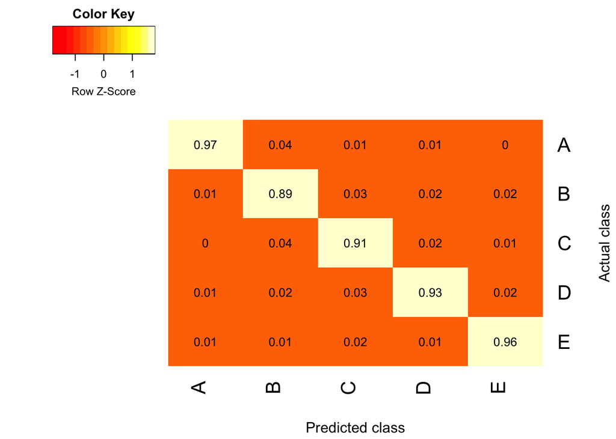

## Predictions on the 20 test cases

As written earlier in this report, a test set is provided. It includes 20 cases that I can predict with our final model. The predictions are below:

```
##  [1] B A B A A E D B A A C C B A E E A B B B
## Levels: A B C D E
```